# Assignment 8

Louis

2022-11-23

# 1. Obstacles to valid scientific inference

1. Measurement distortions Measurement distortions occur whenever there is a mismatch between the quantities recorded within the data and the true variable of interest.  
   *Example*: Suppose we are investigating the effect of a new type of feed on chickens. For the purpose of the experiment a large sample of chickens is split into two groups. One group is given feed type A, and the other feed type B. After some time has elapsed, the chicken’s weights are all measured. Suppose the measuring equipment used to weight the chickens given feed type A had a downward bias. On the other hand, the measuring device used to weight the chickens given feed type B has no such bias. We could then observe a data set where the recorded weights for chickens receiving feed source B typically exceed those receiving feed type A. However, this difference is purely an artefact of the faulty measurement equipment.
2. Selection bias Selection bias occurs whenever the sample included in the analysis misrepresents the underlying population of interest.
1. Sample bias: When some members of the population are more likely to be selected than others.
2. Self selection bias: Occurs whenever people decide whether or not they should be assigned to a particular group.
3. Attrition bias: Occurs whenever the sample is distorted by people leaving the study.
4. Post-hoc selection: Occurs when a subset of the data is chosen based on the sample itself.  
   *Example*: A classic historical example of sample bias is the Literary Digest poll of 1936. In this people were asked about their voting intentions. The prediction was for a 57% victory for Republican Landon over Roosevelt. In fact Roosevelt won the election. The data was collected based upon surveys. These suveys were carried out based upon lists from telephone books and club membership. At the time both telephone ownership and club membership were indicators of wealth, so the sample was biased towards people with higher levels of wealth. At the time, higher levels of wealth were slightly more likely to vote Republican than Democrat. Hence, the selection bias resulted in a misleading result. Subsequent Gallop polls created more accurate results with smaller sample sizes.
3. Confounding variables Suppose that we are interested in understanding the causal effect of an independent variable X on a dependent variable Y. A confounding variable is a third causal factor Z which effects both X and Y. This makes it difficult to disentangle causal effects from purely correlative behavior.  
   *Example*: As an example consider a scientific study into the causal effect of regular cardio-vascular exercise on longevity. Here a confounding variable could be someones overall interest in a healthy lifestyle. This is likely to effect someones via the causal effect of increased cardio-vascular exercise. However, it is likely that an interest in a healthy lifestyle will also effect the amount of fresh fruit and vegetables someone eats, for example. This may also have a causal effect on longevity. Hence, in light of the confounding variables it is difficult to distinguish a causal effect from a purely correlatative relationship.

# 2. paired t-test and effect size

```r
library(PairedData) # you might need to install the package first
data("Barley")
detach('package:PairedData', unload=TRUE)
detach('package:MASS', unload=TRUE)
# unload package because it contains another select() function
head(Barley, 4)
```

```
##   Farm Glabron Velvet
## 1  F01      49     42
## 2  F02      47     47
## 3  F03      39     38
## 4  F04      37     32
```

## Q1

```r
# Carry out a paired t-test to determine whether there is a difference in average yield between the two types of barley.
# Use a significance level of 0.01.
t.test(x=Barley$Glabron, y=Barley$Velvet, paired=TRUE, conf.level=0.99)
```

```
##
##  Paired t-test
##
## data:  Barley$Glabron and Barley$Velvet
## t = 3.0133, df = 11, p-value = 0.0118
## alternative hypothesis: true mean difference is not equal to 0
## 99 percent confidence interval:
##  -0.1816612 12.0149945
## sample estimates:
## mean difference
##        5.916667
```

The p-value is greater than the significance level, we do not reject the hypothsis, so there there is no difference between two types.

## Q2

```r
# Compute the effect size using Cohen’s d statistic
diff <- Barley$Glabron - Barley$Velvet
x_bar <- mean(diff)
s <- sd(diff)
effect_size <- x_bar/s
effect_size
```

```
## [1] 0.8698615
```

## Q3

What assumptions are required for the paired t-test? Are these assumptions justified in this case?

1. Variables were continuous variables
2. Variables are independent
3. There are no significant outliers for the variables
4. The variables are (approximately) normally distributed  
   **We assume that the difference of the two sample is either i.i.d. Gaussian or i.i.d. with a large sample size.**

```r
Barley %>% nrow()
```

```
## [1] 12
```

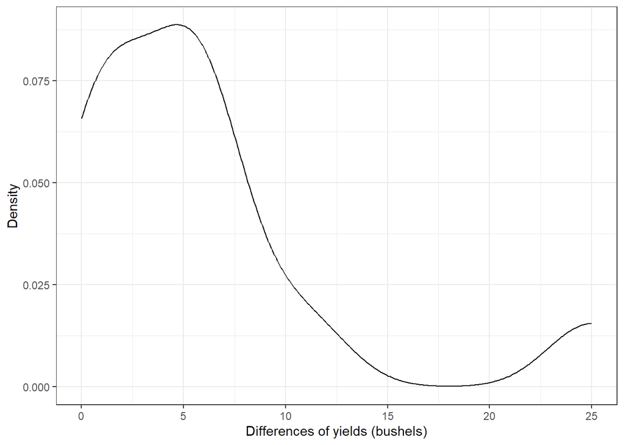

```r
Barley %>%
  mutate(diff=Glabron-Velvet) %>%
  ggplot(aes(x=diff)) + geom_density() + theme_bw() +
  labs(x="Differences of yields (bushels)",y="Density")
```

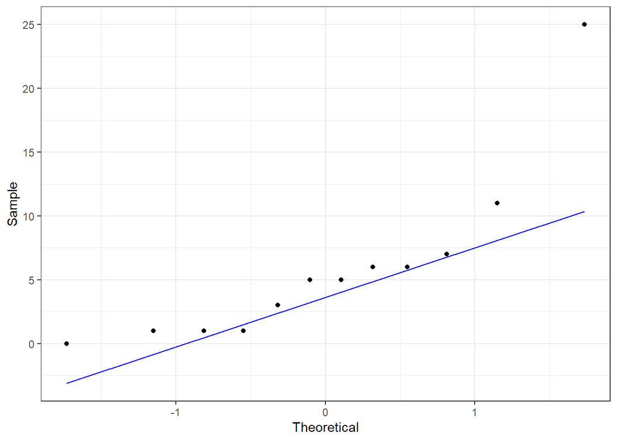

```r
Barley %>%
  mutate(diff=Glabron-Velvet) %>%
  ggplot(aes(sample=diff))+theme_bw()+
  stat_qq()+stat_qq_line(color="blue")+
  labs(x="Theoretical", y="Sample")
```

# 3. Implementing unpaired t-test

```r
# t.test(body_mass_g~species, data=peng_AC,var.equal = TRUE)
library(palmerpenguins)
peng_AC<-penguins %>%
  drop_na(species,body_mass_g) %>%
  filter(species !="Gentoo")
head(peng_AC %>% select(species, flipper_length_mm, body_mass_g), 5)
```

```
## # A tibble: 5 × 3
##   species flipper_length_mm body_mass_g
##   <fct>               <int>       <int>
## 1 Adelie                181        3750
## 2 Adelie                186        3800
## 3 Adelie                195        3250
## 4 Adelie                193        3450
## 5 Adelie                190        3650
```

## Q1

```r
val_col <- "body_mass_g"
group_col <- "species"
data <- peng_AC
data_new <- data %>%
  # rename the columns; note that you can not drop the "!!" (why?)
  rename(group=(!!group_col),val=(!!val_col))%>%
  group_by(group) %>%
  drop_na(val) %>%
  summarise(mn=mean(val))

data_new
```

```
## # A tibble: 2 × 2
##   group        mn
##   <fct>     <dbl>
## 1 Adelie    3701.
## 2 Chinstrap 3733.
```

```r
data_new$mn[2]
```

```
## [1] 3733.088
```

```r
t_test_function <- function(data, val_col, group_col, val_equal=TRUE){
  stats <- data %>%
    # rename the columns; note that you can not drop !! (why?)
    rename(group=(!!group_col),val=(!!val_col))%>%
    group_by(group) %>%
    drop_na(val) %>%
    summarise(mn=mean(val), vr=var(val), n=n())
  pooled_sd <- sqrt(((stats$n[1]-1)*stats$vr[1]+(stats$n[2]-1)*stats$vr[2])/(stats$n[1]+stats$n[2]-2))
  if (val_equal){ # unpaired student t-test
    # test statistic
    t_stat<-(stats$mn[1]-stats$mn[2])/
    (pooled_sd*sqrt(1/stats$n[1]+1/stats$n[2]))
    # degree of freedom
    dof<-stats$n[1]+stats$n[2]-2
  } else { # we can also implement Welch's t-test as follows
    # test statistic
    t_stat=(stats$mn[1]-stats$mn[2])/
    sqrt(stats$vr[1]/stats$n[1]+stats$vr[2]/stats$n[2])
    # degree of freedom
    dof=(stats$vr[1]/stats$n[1]+stats$vr[2]/stats$n[2])^2/((stats$vr[1]/stats$n[1])^2/(stats$n[1]-1)+(stats$vr[2]/stats$n[2])^2/(stats$n[2]-1))
  }
  # p-value
  p_val<- 2*(1-pt(abs(t_stat),df=dof))
  # effect size
  effect_size <- (stats$mn[1]-stats$mn[2])/(pooled_sd)
  return(data.frame(t_stat=t_stat, effect_size=effect_size, p_val=p_val))
}
t_test_function(data=peng_AC,val_col="body_mass_g",group_col="species")
```

```
##       t_stat effect_size     p_val
## 1 -0.5080869 -0.07420226 0.6119085
```

## Q2

```r
t_test_function(data=peng_AC,val_col="body_mass_g",group_col="species", val_equal=FALSE)
```

```
##       t_stat effect_size     p_val
## 1 -0.5430902 -0.07420226 0.5878608
```

```r
t.test(body_mass_g~species, data=peng_AC,var.equal = FALSE)
```

```
##
##  Welch Two Sample t-test
##
## data:  body_mass_g by species
## t = -0.54309, df = 152.45, p-value = 0.5879
## alternative hypothesis: true difference in means between group Adelie and group Chinstrap is not equal to 0
## 95 percent confidence interval:
##  -150.38481   85.53284
## sample estimates:
##    mean in group Adelie mean in group Chinstrap
##                3700.662                3733.088
```

# 4. Useful concepts in statistical hypothesis testing

## Q1

1. The null hypothesis is our default position in a statistical hypothesis which typically declares the absence of some interesting phenomenon for example the equality of two statistical parameters.
2. The alternative hypothesis is a statistical hypothesis which contradicts the null hypothesis and typically declares the presence of some interesting phenomenon, often consistent with the research hypothesis a scientist is attempting to prove. For example, a difference in the values of two statistical parameters.
3. A test statistic is some function of the data used within a statistical hypothesis test. The test statistic must have a known distribution under the null hypothesis. In addition, the test statistic should emphasize differences between null and alternative hypothesis.
4. A type 1 error is a rejection of the null hypothesis in favor of the alternative hypothesis when the null hypothesis is true.
5. A type 2 error is a failure to reject the null hypothesis in favor of the alternative hypothesis when the alternative hypothesis holds.
6. The size of the test is the probability of a type 1 error under the null hypothesis.
7. The power of a test is one minus the probability of a type 2 error under an alternative hypothesis. That is, the probability of rejecting the null hypothesis under an alternative hypothesis. Typically this depends upon the particular alternative hypothesis.
8. The significance level is an upper bound on the size of the test. This should be chosen in advance of seeing the data. A typical value is α = 0.05.
9. The p-value is probability under the null hypothesis that the test statistic will achieve a value as extreme or more extreme than the value which is actually observed. A very small p-value indicates that the observed data is sufficiently inconsistent with the null hypothesis that the null hypothesis can be reasonably rejected.
10. The effect size is a measure of the magnitude of the observed phenomenon which reflects the extent to which the null hypothesis is false.

## Q2

(1). No. The p-value is the probability, under the null hypothesis, of a test-statistic as extreme or more extreme than the observed numerical value. (2). No. For example, it might be the case that the null hypothesis is false, but we have either a small sample size or a relatively small effect size.

# 5. Investigating test size for an unpaired Student’s t-test

## Q1

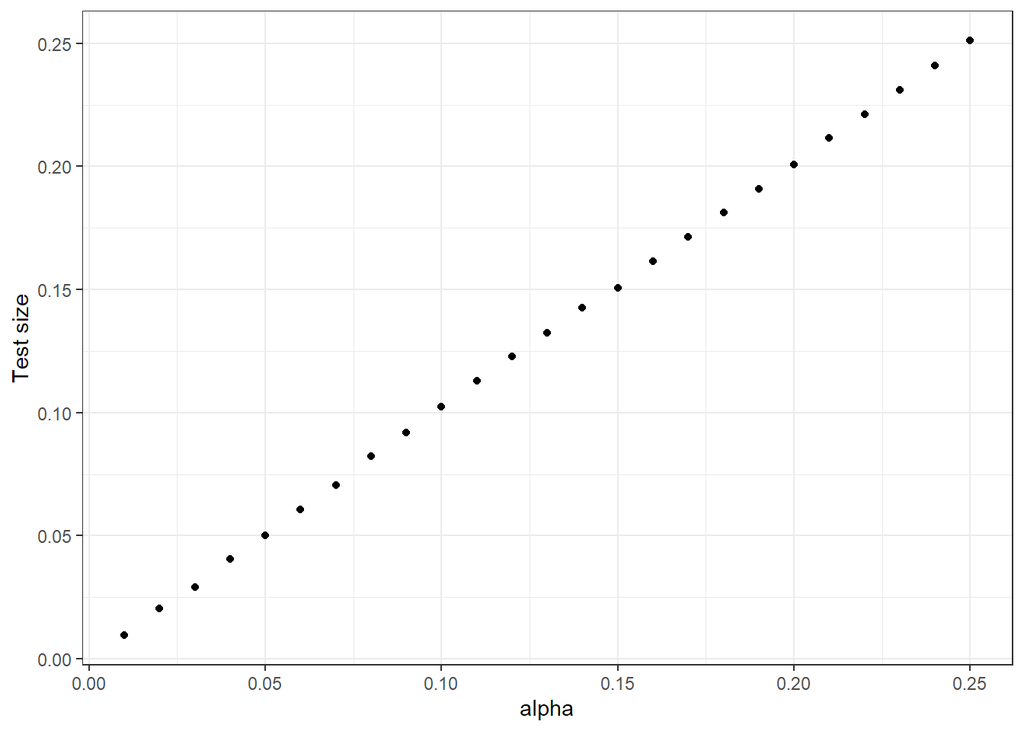

```r
num_trials<-10000
sample_size<-30
mu_0<-1
mu_1<-1
sigma_0<-3
sigma_1<-3
set.seed(0) # set random seed for reproducibility
single_alpha_test_size_simulation_df <- data.frame(trial=seq(num_trials)) %>%
  # generate random Gaussian samples
  mutate(sample_0=map(.x=trial,.f=~rnorm(n=sample_size,mean=mu_0,sd=sigma_0)),
    sample_1=map(.x=trial,.f=~rnorm(n=sample_size,mean=mu_1,sd=sigma_1))) %>%
    # generate p values
  mutate(p_value=pmap(.l=list(trial,sample_0,sample_1),
    .f=~t.test(..2,..3,var.equal = TRUE)$p.value))
alpha_list = seq(0.01, 0.25, 0.01)
compute_test_size <- function(alpha){
  # type I error
  type_1_error = single_alpha_test_size_simulation_df$p_value<alpha
  return (mean(type_1_error)) # estimate of coverage probability
}
multiple_alpha_test_size_simulation_df <- data.frame(alpha=alpha_list) %>%
  mutate(test_size = map_dbl(alpha, compute_test_size))
multiple_alpha_test_size_simulation_df %>% ggplot(aes(x=alpha, y=test_size)) +
  geom_point() + ylab('Test size') + theme_bw()
```

# 6. The statistical power of an unpaired t-test

## Q1

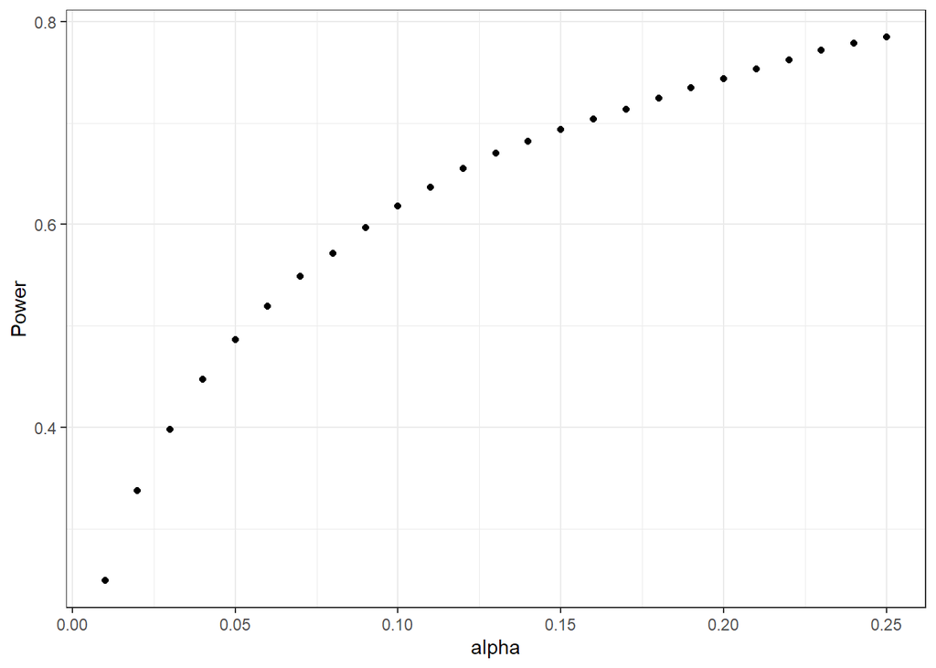

```r
num_trials<-10000
n_0<-30
n_1<-30
mu_0<-3
mu_1<-4
sigma_0<-2
sigma_1<-2
alpha<-0.05
set.seed(0) # set random seed for reproducibility
single_alpha_power_df <- data.frame(trial=seq(num_trials)) %>%
  # generate random Gaussian samples
  mutate(sample_0 = map(.x=trial,.f =~ rnorm(n=n_0,mean=mu_0,sd=sigma_0)),
    sample_1 = map(.x=trial,.f =~ rnorm(n=n_1,mean=mu_1,sd=sigma_1))) %>%
  # for each sample, generate p value; check examples of pmap() with ?map
  mutate(p_value=pmap(.l = list(trial,sample_0,sample_1),
    .f =~ t.test(..2, ..3, var.equal = TRUE)$p.value))

compute_power <- function(alpha){
  reject_null <- single_alpha_power_df$p_value < alpha
  return (mean(reject_null))
}

multiple_alpha_power_df <- data.frame(alpha=seq(0.01, 0.25, 0.01)) %>%
  mutate(power= map_dbl(alpha, compute_power))
multiple_alpha_power_df %>% ggplot(aes(x=alpha, y=power)) +
  geom_point() + ylab('Power') + theme_bw()
```

## Q2

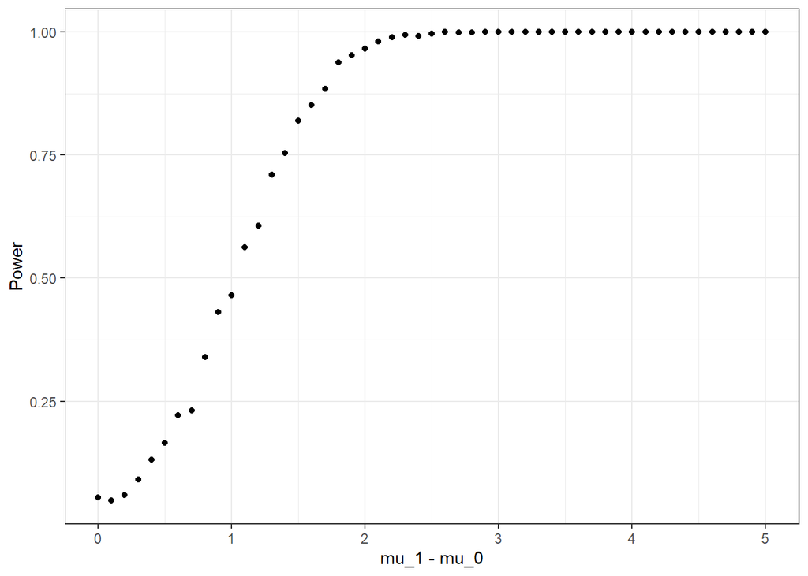

```r
num_trials<-1000
n_0<-30
n_1<-30
mu_0<-3
# mu_1<-4
sigma_0<-2
sigma_1<-2
alpha<-0.05
set.seed(0) # set random seed for reproducibility

compute_power_from_mu1 <- function(mu_1){
  single_mu1_power_df <- data.frame(trial=seq(num_trials)) %>%
    # generate random Gaussian samples
    mutate(sample_0 = map(.x=trial,.f =~ rnorm(n=n_0,mean=mu_0,sd=sigma_0)),
           sample_1 = map(.x=trial,.f =~ rnorm(n=n_1,mean=mu_1,sd=sigma_1))) %>%
    # for each sample, generate p value; check examples of pmap() with ?map
    mutate(p_value=pmap(.l = list(trial,sample_0,sample_1),
                        .f =~ t.test(..2, ..3, var.equal = TRUE)$p.value))

reject_null <- single_mu1_power_df$p_value < alpha
  return (mean(reject_null))
}

multiple_mu1_power_df <- data.frame(mu_1=seq(3.0, 8.0, 0.1)) %>%
  mutate(power= map_dbl(mu_1, compute_power_from_mu1))

multiple_mu1_power_df %>% ggplot(aes(x=mu_1-mu_0, y=power)) +
  geom_point() + ylab('Power') + theme_bw()
```

## Q3

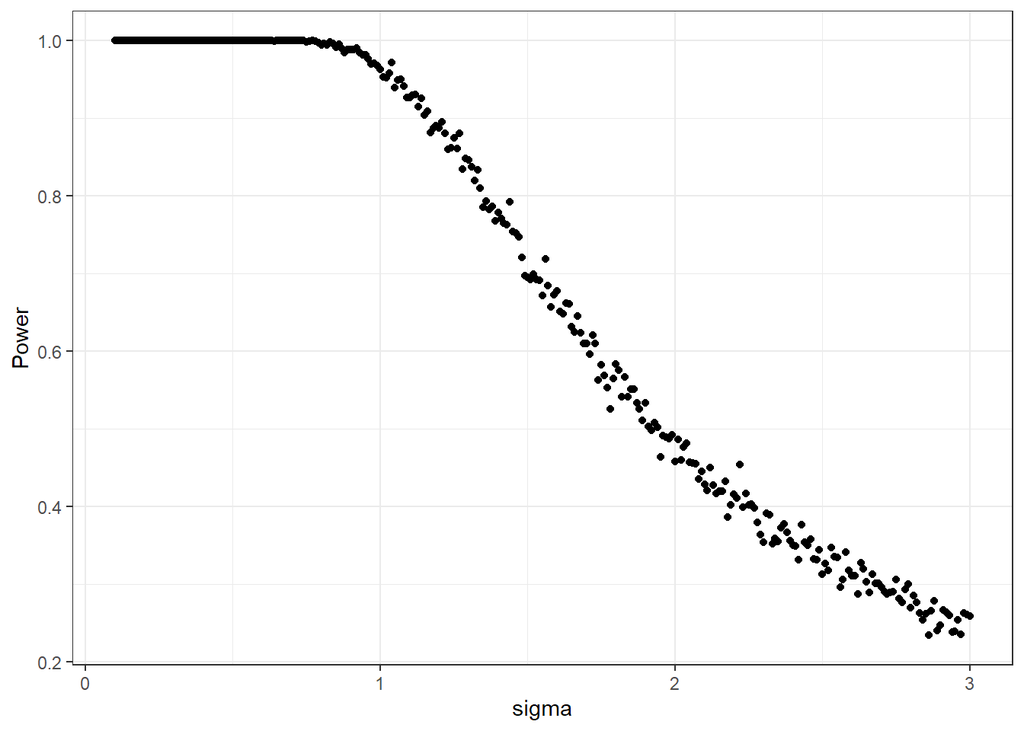

```r
num_trials<-1000
n_0<-30
n_1<-30
mu_0<-3
mu_1<-4
#sigma_0<-2
#sigma_1<-2
alpha<-0.05
set.seed(0) # set random seed for reproducibility

compute_power_from_sigma <- function(sigma){
  sigma_0 <- sigma
  sigma_1 <- sigma
  single_sigma_power_df <- data.frame(trial=seq(num_trials)) %>%
    # generate random Gaussian samples
    mutate(sample_0 = map(.x=trial,.f =~ rnorm(n=n_0,mean=mu_0,sd=sigma_0)),
           sample_1 = map(.x=trial,.f =~ rnorm(n=n_1,mean=mu_1,sd=sigma_1))) %>%
    # for each sample, generate p value; check examples of pmap() with ?map
    mutate(p_value=pmap(.l = list(trial,sample_0,sample_1),
                        .f =~ t.test(..2, ..3, var.equal = TRUE)$p.value))

  reject_null <- single_sigma_power_df$p_value < alpha
  return (mean(reject_null))
}
multiple_sigma_power_df <- data.frame(sigma=seq(0.1, 3.0, 0.01)) %>%
  mutate(power= map_dbl(sigma, compute_power_from_sigma))

multiple_sigma_power_df %>% ggplot(aes(x=sigma, y=power)) +
  geom_point() + ylab('Power') + theme_bw()
```

## Q4

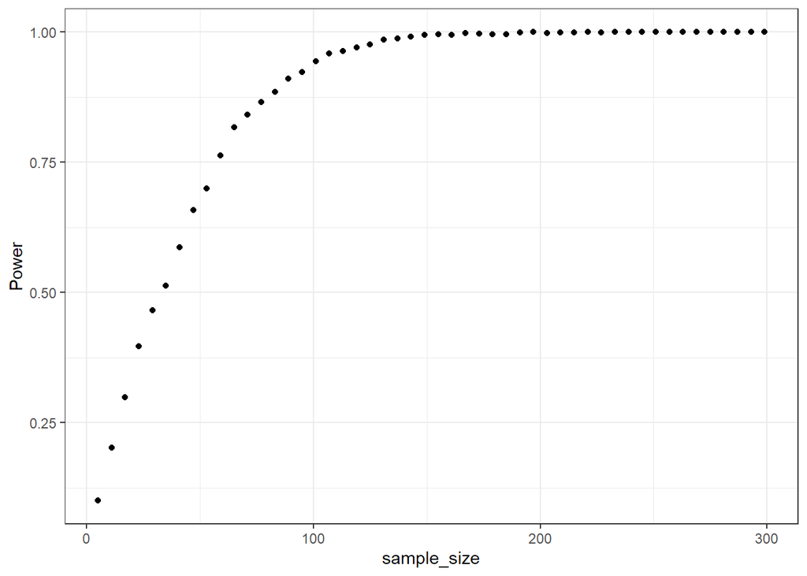

```r
num_trials<-1000
#n_0<-30
#n_1<-30
mu_0<-3
mu_1<-4
sigma_0<-2
sigma_1<-2
alpha<-0.05
set.seed(0) # set random seed for reproducibility

compute_power_from_sz <- function(sz){
  n_0 <- sz
  n_1 <- sz
  single_sigma_power_df <- data.frame(trial=seq(num_trials)) %>%
    # generate random Gaussian samples
    mutate(sample_0 = map(.x=trial,.f =~ rnorm(n=n_0,mean=mu_0,sd=sigma_0)),
           sample_1 = map(.x=trial,.f =~ rnorm(n=n_1,mean=mu_1,sd=sigma_1))) %>%
    # for each sample, generate p value; check examples of pmap() with ?map
    mutate(p_value=pmap(.l = list(trial,sample_0,sample_1),
                        .f =~ t.test(..2, ..3, var.equal = TRUE)$p.value))
  reject_null <- single_sigma_power_df$p_value < alpha
  return (mean(reject_null))
}

multiple_sz_power_df <- data.frame(sample_size=seq(5, 300, 6)) %>%
  mutate(power= map_dbl(sample_size, compute_power_from_sz))

multiple_sz_power_df %>% ggplot(aes(x=sample_size, y=power)) +
  geom_point() + ylab('Power') + theme_bw()
```

# 7. (*Optional) Comparing the paired and unpaired t-tests on paired data

## Q1

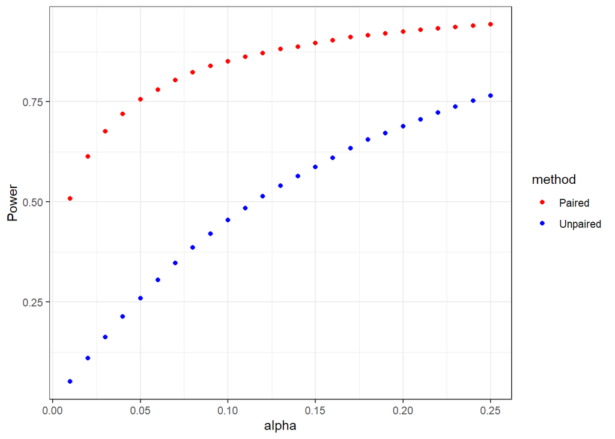

```r
num_trials<-10000
n_0<-30
n_1<-30
mu_0<-3
mu_Z<-1 # mean of Z
sigma_0<-2
sigma_Z<-2
alpha<-0.05
set.seed(0) # set random seed for reproducibility

single_alpha_power_df <- data.frame(trial=seq(num_trials)) %>%
  # generate random Gaussian samples
  mutate(sample_0 = map(.x=trial,.f =~ rnorm(n=n_0,mean=mu_0,sd=sigma_0)) ) %>%
  mutate(sample_Z = map(.x=trial,.f =~ rnorm(n=n_0,mean=mu_Z,sd=sigma_Z)) ) %>%
  mutate(sample_1 = pmap(.l=list(sample_0, sample_Z),.f =~ (..1+..2))) %>%
  # for each sample, generate p value; check examples of pmap() with ?map
  mutate(p_value_paired=pmap(.l = list(trial,sample_0,sample_1),
                             .f =~ t.test(..2, ..3, paired=TRUE)$p.value)) %>%
  mutate(p_value_unpaired=pmap(.l = list(trial,sample_0,sample_1),
                               .f =~ t.test(..2, ..3, paired=FALSE)$p.value))

compute_power_paired <- function(alpha){
  reject_null <- single_alpha_power_df$p_value_paired < alpha
  return (mean(reject_null))
}

compute_power_unpaired <- function(alpha){
  reject_null <- single_alpha_power_df$p_value_unpaired < alpha
  return (mean(reject_null))
}

multiple_alpha_power_df <- data.frame(alpha=seq(0.01, 0.25, 0.01)) %>%
  mutate(power_paired= map_dbl(alpha, compute_power_paired)) %>%
  mutate(power_unpaired= map_dbl(alpha, compute_power_unpaired))

colors <- c('Paired'='red', 'Unpaired'='blue')

multiple_alpha_power_df %>% ggplot() +
  geom_point(aes(x=alpha, y=power_paired, color='Paired')) +
  geom_point(aes(x=alpha, y=power_unpaired, color='Unpaired')) + ylab('Power') +
  theme_bw() + scale_color_manual(name = "method", values=colors)
```